# Workshop 10 Solutions

Veerasak

We’ll begin by loading some packages.

```r
library(MASS)
library(plyr)
```

### Interaction terms in regression

```r
# Building up the familiar birthwt data...

# Rename the columns to have more descriptive names
colnames(birthwt) <- c("birthwt.below.2500", "mother.age", "mother.weight",
    "race", "mother.smokes", "previous.prem.labor", "hypertension", "uterine.irr",
    "physician.visits", "birthwt.grams")

# Transform variables to factors with descriptive levels
birthwt <- transform(birthwt,
            race = as.factor(mapvalues(race, c(1, 2, 3),
                              c("white","black", "other"))),
            mother.smokes = as.factor(mapvalues(mother.smokes,
                              c(0,1), c("no", "yes"))),
            hypertension = as.factor(mapvalues(hypertension,
                              c(0,1), c("no", "yes"))),
            uterine.irr = as.factor(mapvalues(uterine.irr,
                              c(0,1), c("no", "yes")))
            )
```

**(a)** Run a linear regression to better understand how birthweight varies with the mother’s age and smoking status (do not include interaction terms).

```r
# Run regression model
birthwt.lm <- lm(birthwt.grams ~ mother.age + mother.smokes, data = birthwt)

# Output coefficients table
summary(birthwt.lm)
```

```
##
## Call:
## lm(formula = birthwt.grams ~ mother.age + mother.smokes, data = birthwt)
##
## Residuals:
##      Min       1Q   Median       3Q      Max
## -2119.98  -442.66    52.92   532.38  1690.74
##
## Coefficients:
##                  Estimate Std. Error t value Pr(>|t|)
## (Intercept)      2791.224    240.950  11.584   <2e-16 ***
## mother.age         11.290      9.881   1.143    0.255
## mother.smokesyes -278.356    106.987  -2.602    0.010 *
## ---
## Signif. codes:  0 '***' 0.001 '**' 0.01 '*' 0.05 '.' 0.1 ' ' 1
##
## Residual standard error: 717.2 on 186 degrees of freedom
## Multiple R-squared:  0.04299,    Adjusted R-squared:  0.0327
## F-statistic: 4.177 on 2 and 186 DF,  p-value: 0.0168
```

**(b)** What is the coefficient of mother.age in your regression? How do you interpret this coefficient?

```r
coef(birthwt.lm)["mother.age"]
```

```
## mother.age
##   11.28961
```

```r
age.coef <- round(coef(birthwt.lm)["mother.age"], 1)
```

**Note: This solution uses inline code chunks.** The coefficient is 11.3. This means that among mothers with the same smoking status, each additional year of age is on average associated with a 11.3g increase in birthweight.

**(c)** How many coefficients are estimated for the mother’s smoking status variable? How do you interpret these coefficients?

```r
coef(birthwt.lm)["mother.smokesyes"]
```

```
## mother.smokesyes
##        -278.3561
```

```r
smoke.coef <- abs(round(coef(birthwt.lm)["mother.smokesyes"], 1))
```

**Note: This solution uses inline code chunks.** There is just one coefficient estimated. This coefficient gives us the average difference in birthweight between mothers that smoke and mother’s that don’t, in a model that adjusts for the effect of mother’s age. That is, after we adjust for the effect of age, smoking leads to an average 278.4 decrease in birthweight.

**(d)** Using ggplot, construct a scatterplot with birthweight on the y-axis and mother’s age on the x-axis. Color the points by mother’s smoking status, and add smoking status-specific linear regression lines using the `stat_smooth` layer.

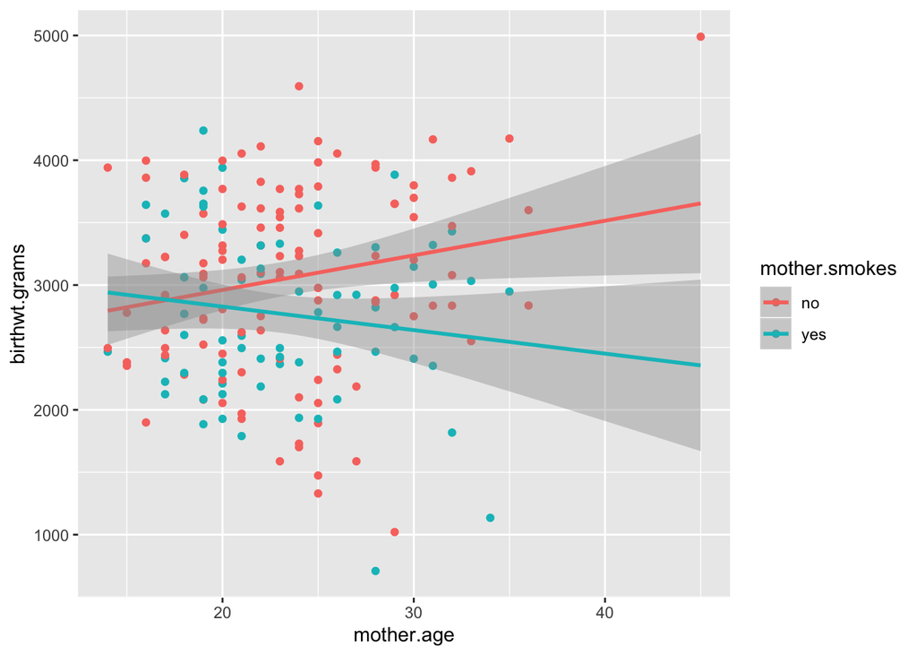

```r
library(ggplot2)
# Note fullrange = TRUE is used here to extend the 'mother.smokes = yes' line beyond the maximum age (35) in this group
qplot(data = birthwt, x = mother.age, y = birthwt.grams, colour = mother.smokes) + stat_smooth(method = "lm", fullrange = TRUE)
```